# Estimating Travel Times Using the *osrm* Package

PLAN 6122 Supplement

Bev Wilson

Last Updated 2023-04-23

Several students have expressed an interest in using the *osrm* package to [calculate travel times](https://cran.r-project.org/web/packages/osrm/index.html) along a transportation network from a set of origins to a set of destinations. This document offers a brief demonstration of how you might do this. This package is a way to interact with [this web-based routing application](https://project-osrm.org) that you can also use directly from your browser.

The *osrm* package can return travel times (i.e., durations) and travel distances (i.e., distances) between origins and destinations **along the OpenStreetMap road network** by making calls to an API. This means you **do not** need to download a road network. You should review the documentation for this package, but the main functions of interest are:

- [osrmTable](https://search.r-project.org/CRAN/refmans/osrm/html/osrmTable.html): Build and send OSRM API queries to get travel time matrices between points.
- [osrmRoute](https://search.r-project.org/CRAN/refmans/osrm/html/osrmRoute.html): Build and send an OSRM API query to get the travel geometry between two points.
- [osrmTrip](https://search.r-project.org/CRAN/refmans/osrm/html/osrmTrip.html): Build and send an OSRM API query to get the shortest travel geometry between multiple unordered points.
- [osrmNearest](https://search.r-project.org/CRAN/refmans/osrm/html/osrmNearest.html): Build and send an OSRM API query to get the nearest point on the street network.
- [osrmIsochrone](https://search.r-project.org/CRAN/refmans/osrm/html/osrmIsochrone.html): This function computes areas that are reachable within a given time span from a point and returns the reachable regions as polygons. These areas of equal travel time are called isochrones.
- [osrmIsodistance](https://search.r-project.org/CRAN/refmans/osrm/html/osrmIsodistance.html): This function computes areas that are reachable within a given road distance from a point and returns the reachable regions as polygons. These areas of equal travel distance are called isodistances.

The example presented here uses a polygon layer provided by the City of Charlottesville as part of its 2023 zoning ordinance update that shows the location and proposed future land use designation of all parcels in the city [downloaded from here](https://cvilleplanstogether.com/draft-zoning/) and provided a shapefile with this .Rmd. The other data layer is the location of all public schools in the city.

The API is free to use but it [does implement throttling](https://www.tibco.com/reference-center/what-is-api-throttling#:~:text=API%20throttling%20is%20the%20process,click%20triggers%20an%20API%20call.) which means that depending on the level of demand from users around the world, you may be able to request 1,000 responses or only 200 responses at a time. In my experience, “off hours” and nights are when you make larger calls to the API. Otherwise, the strategy is to break your data into pieces and send each of those pieces over to the API as a separate request so as to not exceed the current limit. If you are [comfortable with for loops](https://info201.github.io/control-structures.html#control-structures) you could set up a routine where your data are broken into the requisite number of pieces and sent to the API automatically while you sleep or watch a movie. This example shows how this approach would be implemented manually to make it easier to understand and follow because sometimes loops can obfuscate.

# Data Wrangling

This example focuses on one neighborhood—Fifeville 😄 First, we extract the polygon we want, then we extract the parcel centroids that fall within the Fifeville neighborhood boundary.

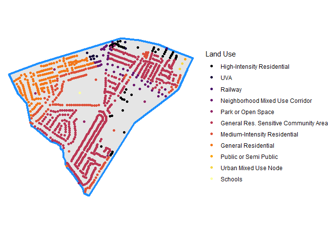

```r
# Extract the Fifeville neighborhood only...
fifeville <- nhoods[nhoods$NAME == "Fifeville", ]

# Select parcels in Fifeville...

fifeville_parcels_polys <- st_intersection(draft_zoning, fifeville)

fifeville_parcels <- st_intersection(draft_zoning, fifeville) %>%
  st_centroid()


# Visualize parcel centroids by future land use designation...
ggplot() +
  geom_sf(data = fifeville, color = "dodgerblue", linewidth = 1.5) +
  geom_sf(data = fifeville_parcels, aes(color = as_factor(FLUM_Desig))) +
  scale_color_viridis(name = "Land Use", option = "inferno", discrete = TRUE) +
  theme_void()
```

# Requesting the Data

The code chunk below requests the time (minutes) and the distance (meters) from each origin in the parcel centroids layer to each destination in the schools layer along the OpenStreetMap road network for Charlottesville. Take a look at the `osrmTable` function arguments and note that **osrm.profile** determines whether walk times, driving times, etc. are returned. In this example, we request walking times in both minutes and meters.

```r
# Create an object to hold the processed data...

output_300 <- tibble(UniqueID=character(), NearSchoolDist=character(), NearSchoolMins=character(),
                     DistMeters=double(), TimeMins=double())

# Make the API request for rows 1 through 300 of the parcel centroids layer to avoid
# exceeding API throttling limits...
foot_matrix_300 <- osrmTable(src = fifeville_parcels[1:300, ], dst = schools,
                         osrm.profile = "foot", measure = c("duration", "distance"))


# Because the previous function returns a 300 x 9 object in a nested list, we need to
# pull out the information we actually need... the durations and distances are stored
# separately in the nested list, but we process both in the loop below...

for (j in (seq(1:dim(foot_matrix_300$durations)[1]))) {

  foot_matrix_distance_final <- suppressMessages(
    bind_cols(fifeville_parcels$ParcelNumb[1:300], foot_matrix_300$distances)
  )
  foot_matrix_durations_final <- suppressMessages(
    bind_cols(fifeville_parcels$ParcelNumb[1:300], foot_matrix_300$durations)
  )

  colnames(foot_matrix_distance_final) <- c("KeyField", str_replace(as.vector(schools$name), "-", ""))
  rownames(foot_matrix_distance_final) <- NULL
  colnames(foot_matrix_durations_final) <- c("KeyField", str_replace(as.vector(schools$name), "-", ""))
  rownames(foot_matrix_durations_final ) <- NULL

  parcel_id <- foot_matrix_distance_final$KeyField[j]
  nearest_school_distance <- names(foot_matrix_distance_final[j,])[apply(foot_matrix_distance_final[j,], MARGIN = 1, FUN = which.min)]
  nearest_school_time <- names(foot_matrix_durations_final[j,])[apply(foot_matrix_durations_final[j,], MARGIN = 1, FUN = which.min)]
  dist_meters <- foot_matrix_distance_final[j,][apply(foot_matrix_distance_final[j,], MARGIN = 1,  FUN = which.min)][[1]]
  time_mins <- foot_matrix_durations_final[j,][apply(foot_matrix_durations_final[j,], MARGIN = 1,  FUN = which.min)][[1]]
  this_parcel <- suppressMessages(
    bind_cols(parcel_id, nearest_school_distance[1], nearest_school_time[1], dist_meters[1], time_mins[1])
  )

  colnames(this_parcel) <- c("UniqueID", "NearSchoolDist",  "NearSchoolMins", "DistMeters", "TimeMins")
  rownames(this_parcel)  <- NULL
  output_300 <- rbind(output_300, this_parcel)


}

# We now have the information we want for the first 300 parcel centroids...
str(output_300)
```

```
## tibble [300 × 5] (S3: tbl_df/tbl/data.frame)
##  $ UniqueID      : chr [1:300] "300009000" "300010000" "300008000" "290070300" ...
##  $ NearSchoolDist: chr [1:300] "Buford Middle School" "Buford Middle School" "Buford Middle School" "Buford Middle School" ...
##  $ NearSchoolMins: chr [1:300] "Buford Middle School" "Buford Middle School" "Buford Middle School" "Buford Middle School" ...
##  $ DistMeters    : num [1:300] 772 799 720 1234 726 ...
##  $ TimeMins      : num [1:300] 10.3 10.7 9.6 16.4 9.7 13.9 8.2 10.2 9.2 8.8 ...
```

Next, we do it again **making sure that we request rows 301 through 600** to avoid duplicating the previous code chunk. Eventually, we will append all of these outputs once all 1,134 parcels in Fifeville have been processed.

> I’ve started investing in stocks. Beef, Chicken, and Vegetable.

> One day I hope to be a bouillionaire. 😆

```r
# Create an object to hold the processed data...
output_600 <- tibble(UniqueID=character(), NearSchoolDist=character(), NearSchoolMins=character(),
                     DistMeters=double(), TimeMins=double())

foot_matrix_600 <- osrmTable(src = fifeville_parcels[301:600, ], dst = schools,
                         osrm.profile = "foot", measure = c("duration", "distance"))


for (j in (seq(1:dim(foot_matrix_600$durations)[1]))) {

  foot_matrix_distance_final <- suppressMessages(
    bind_cols(fifeville_parcels$ParcelNumb[301:600], foot_matrix_600$distances)
  )
  foot_matrix_durations_final <- suppressMessages(
    bind_cols(fifeville_parcels$ParcelNumb[301:600], foot_matrix_600$durations)
  )

  colnames(foot_matrix_distance_final) <- c("KeyField", str_replace(as.vector(schools$name), "-", ""))
  rownames(foot_matrix_distance_final) <- NULL
  colnames(foot_matrix_durations_final) <- c("KeyField", str_replace(as.vector(schools$name), "-", ""))
  rownames(foot_matrix_durations_final ) <- NULL

  parcel_id <- foot_matrix_distance_final$KeyField[j]
  nearest_school_distance <- names(foot_matrix_distance_final[j,])[apply(foot_matrix_distance_final[j,], MARGIN = 1, FUN = which.min)]
  nearest_school_time <- names(foot_matrix_durations_final[j,])[apply(foot_matrix_durations_final[j,], MARGIN = 1, FUN = which.min)]
  dist_meters <- foot_matrix_distance_final[j,][apply(foot_matrix_distance_final[j,], MARGIN = 1,  FUN = which.min)][[1]]
  time_mins <- foot_matrix_durations_final[j,][apply(foot_matrix_durations_final[j,], MARGIN = 1,  FUN = which.min)][[1]]
  this_parcel <- suppressMessages(
    bind_cols(parcel_id, nearest_school_distance[1], nearest_school_time[1], dist_meters[1], time_mins[1])
  )

  colnames(this_parcel) <- c("UniqueID", "NearSchoolDist",  "NearSchoolMins", "DistMeters", "TimeMins")
  rownames(this_parcel)  <- NULL
  output_600 <- rbind(output_600, this_parcel)


}

# We now have the information we want for the NEXT 300 parcel centroids...
str(output_600)
```

```
## tibble [300 × 5] (S3: tbl_df/tbl/data.frame)
##  $ UniqueID      : chr [1:300] "230076000" "290219000" "230066000" "290124000" ...
##  $ NearSchoolDist: chr [1:300] "Buford Middle School" "Buford Middle School" "Buford Middle School" "Buford Middle School" ...
##  $ NearSchoolMins: chr [1:300] "Buford Middle School" "Buford Middle School" "Buford Middle School" "Buford Middle School" ...
##  $ DistMeters    : num [1:300] 583 676 387 1177 657 ...
##  $ TimeMins      : num [1:300] 7.8 9 5.2 15.7 8.8 12.8 5.8 13.9 14.5 9 ...
```

Now we need to run a modified version of the preceding code but **making sure that we request rows 601 through 900** to avoid duplicating the previous chunk.

```r
# Create an object to hold the processed data...
output_900 <- tibble(UniqueID=character(), NearSchoolDist=character(), NearSchoolMins=character(),
                     DistMeters=double(), TimeMins=double())

foot_matrix_900 <- osrmTable(src = fifeville_parcels[601:900, ], dst = schools,
                         osrm.profile = "foot", measure = c("duration", "distance"))


for (j in (seq(1:dim(foot_matrix_900$durations)[1]))) {

  foot_matrix_distance_final <- suppressMessages(
    bind_cols(fifeville_parcels$ParcelNumb[601:900], foot_matrix_900$distances)
  )
  foot_matrix_durations_final <- suppressMessages(
    bind_cols(fifeville_parcels$ParcelNumb[601:900], foot_matrix_900$durations)
  )

  colnames(foot_matrix_distance_final) <- c("KeyField", str_replace(as.vector(schools$name), "-", ""))
  rownames(foot_matrix_distance_final) <- NULL
  colnames(foot_matrix_durations_final) <- c("KeyField", str_replace(as.vector(schools$name), "-", ""))
  rownames(foot_matrix_durations_final ) <- NULL

  parcel_id <- foot_matrix_distance_final$KeyField[j]
  nearest_school_distance <- names(foot_matrix_distance_final[j,])[apply(foot_matrix_distance_final[j,], MARGIN = 1, FUN = which.min)]
  nearest_school_time <- names(foot_matrix_durations_final[j,])[apply(foot_matrix_durations_final[j,], MARGIN = 1, FUN = which.min)]
  dist_meters <- foot_matrix_distance_final[j,][apply(foot_matrix_distance_final[j,], MARGIN = 1,  FUN = which.min)][[1]]
  time_mins <- foot_matrix_durations_final[j,][apply(foot_matrix_durations_final[j,], MARGIN = 1,  FUN = which.min)][[1]]
  this_parcel <- suppressMessages(
    bind_cols(parcel_id, nearest_school_distance[1], nearest_school_time[1], dist_meters[1], time_mins[1])
  )

  colnames(this_parcel) <- c("UniqueID", "NearSchoolDist",  "NearSchoolMins", "DistMeters", "TimeMins")
  rownames(this_parcel)  <- NULL
  output_900 <- rbind(output_900, this_parcel)


}


# We now have the information we want for the NEXT 300 parcel centroids...
str(output_900)
```

```
## tibble [300 × 5] (S3: tbl_df/tbl/data.frame)
##  $ UniqueID      : chr [1:300] "240010000" "240011000" "230123000" "240012000" ...
##  $ NearSchoolDist: chr [1:300] "Buford Middle School" "Buford Middle School" "Johnson Elementary School" "Buford Middle School" ...
##  $ NearSchoolMins: chr [1:300] "Buford Middle School" "Buford Middle School" "Johnson Elementary School" "Buford Middle School" ...
##  $ DistMeters    : num [1:300] 433 414 802 394 346 472 353 714 472 920 ...
##  $ TimeMins      : num [1:300] 5.8 5.5 10.7 5.2 4.6 6.3 4.7 9.5 6.3 12.3 ...
```

Finally, we need to run a modified version of the preceding code **one more time** but **making sure that we request rows 901 through 1134** to avoid duplicating the previous chunk.

```r
# Create an object to hold the processed data...

output_1134 <- tibble(UniqueID=character(), NearSchoolDist=character(), NearSchoolMins=character(),
                     DistMeters=double(), TimeMins=double())

foot_matrix_1134 <- osrmTable(src = fifeville_parcels[901:1134, ], dst = schools,
                         osrm.profile = "foot", measure = c("duration", "distance"))


for (j in (seq(1:dim(foot_matrix_1134$durations)[1]))) {

  foot_matrix_distance_final <- suppressMessages(
    bind_cols(fifeville_parcels$ParcelNumb[901:1134], foot_matrix_1134$distances)
  )
  foot_matrix_durations_final <- suppressMessages(
    bind_cols(fifeville_parcels$ParcelNumb[901:1134], foot_matrix_1134$durations)
  )

  colnames(foot_matrix_distance_final) <- c("KeyField", str_replace(as.vector(schools$name), "-", ""))
  rownames(foot_matrix_distance_final) <- NULL
  colnames(foot_matrix_durations_final) <- c("KeyField", str_replace(as.vector(schools$name), "-", ""))
  rownames(foot_matrix_durations_final ) <- NULL

  parcel_id <- foot_matrix_distance_final$KeyField[j]
  nearest_school_distance <- names(foot_matrix_distance_final[j,])[apply(foot_matrix_distance_final[j,], MARGIN = 1, FUN = which.min)]
  nearest_school_time <- names(foot_matrix_durations_final[j,])[apply(foot_matrix_durations_final[j,], MARGIN = 1, FUN = which.min)]
  dist_meters <- foot_matrix_distance_final[j,][apply(foot_matrix_distance_final[j,], MARGIN = 1,  FUN = which.min)][[1]]
  time_mins <- foot_matrix_durations_final[j,][apply(foot_matrix_durations_final[j,], MARGIN = 1,  FUN = which.min)][[1]]
  this_parcel <- suppressMessages(
    bind_cols(parcel_id, nearest_school_distance[1], nearest_school_time[1], dist_meters[1], time_mins[1])
  )

  colnames(this_parcel) <- c("UniqueID", "NearSchoolDist",  "NearSchoolMins", "DistMeters", "TimeMins")
  rownames(this_parcel)  <- NULL
  output_1134 <- rbind(output_1134, this_parcel)


}


# We now have the information we want for the FINAL batch of parcel centroids...
str(output_1134)
```

```
## tibble [234 × 5] (S3: tbl_df/tbl/data.frame)
##  $ UniqueID      : chr [1:234] "22B270000" "22B261000" "250124000" "22B271000" ...
##  $ NearSchoolDist: chr [1:234] "Buford Middle School" "Buford Middle School" "Buford Middle School" "Buford Middle School" ...
##  $ NearSchoolMins: chr [1:234] "Buford Middle School" "Buford Middle School" "Buford Middle School" "Buford Middle School" ...
##  $ DistMeters    : num [1:234] 1019 1067 1073 1030 945 ...
##  $ TimeMins      : num [1:234] 13.6 14.2 14.3 13.7 12.6 14.3 14.4 14.5 13.9 12.7 ...
```

Now for the fun part—combining the data objects we have created and visualizing the results 💪

```r
# Append the data objects created above...
fifeville_out <- bind_rows(output_300, output_600, output_900, output_1134) %>%
  drop_na(UniqueID)

# Save it for later...
write_csv(fifeville_out, "./output/fifeville_travel_times_and_distances_to_schools.csv")

# Link data back to the polygon geometry...
fifeville_to_plot <- inner_join(fifeville_parcels_polys, fifeville_out, by = c("ParcelNumb" = "UniqueID"))

# Save this for later too...
st_write(fifeville_to_plot, "./output/fifeville_travel_times_and_distances_to_schools.geojson")
```

```
## Writing layer `fifeville_travel_times_and_distances_to_schools' to data source
##   `./output/fifeville_travel_times_and_distances_to_schools.geojson' using driver `GeoJSON'
## Writing 1128 features with 18 fields and geometry type Unknown (any).
```

```r
# Are there schools inside the neighborhood boundary?
local_schools <- st_intersection(schools, fifeville)
```

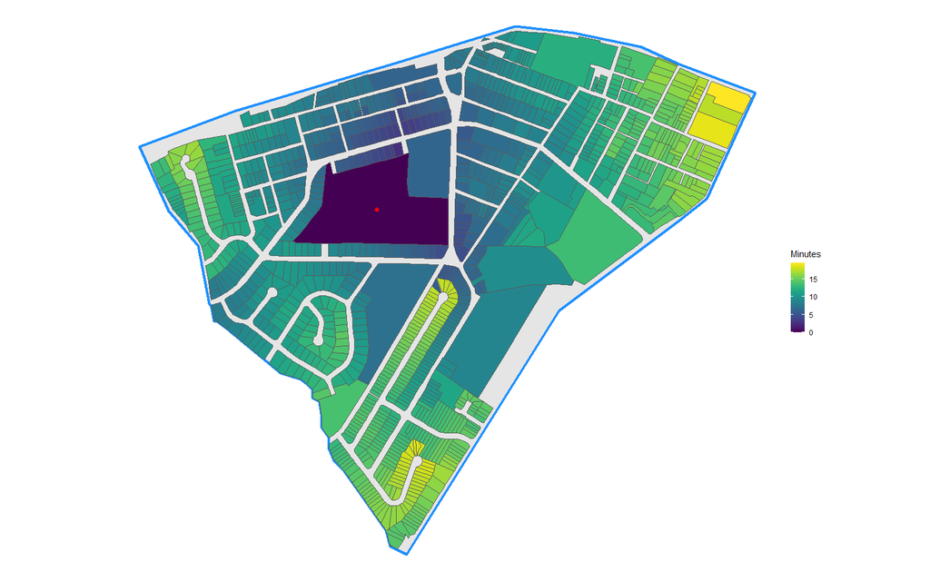

```r
# Map walk time to the nearest school...
ggplot() +
  geom_sf(data = fifeville, color = "dodgerblue", linewidth = 1.5) +
  geom_sf(data = fifeville_to_plot, aes(fill = TimeMins)) +
  geom_sf(data = st_centroid(local_schools), color = "red", pch = 19, size = 2) +
  scale_fill_viridis(name = "Minutes") +
  theme_void()
```

```r
# For most parcels, Buford Middle is closest...
fifeville_to_plot %>%
  st_drop_geometry() %>%
  tabyl(NearSchoolMins)
```

```
##                  NearSchoolMins   n      percent
##            Buford Middle School 993 0.8803191489
##         Clark Elementary School   1 0.0008865248
##  Jackson  Via Elementary School  16 0.0141843972
##       Johnson Elementary School 118 0.1046099291
```

You have reached the end!

Celebrate! 🥳

© Bev Wilson 2023 | Department of Urban + Environmental Planning | University of Virginia